# FRONT ROW CREW - Homework 5

Statistical Inference 1

11/22/2017

```r
require(ggplot2)
```

# Guidelines

- This is a group project. You may work in groups with up to 6 people. You only need to turn in one homework assignment for each group, but make sure that everyone’s name is listed on the assignment.
- Also, even if you don’t write the code for every part of the assignment, you should practice the skills in each section.
- This assignment focuses on simulating data that violates various assumptions of the linear regression model.
- Some sample code has been included, but you will need to try many different starting values for the parameters, sample size, and distributional assumptions. The included code is just to give you a starting point; it should not be considered sufficient to answer all the questions in each part. (And you are welcome to ignore the sample code and use your own)

```r
check_violations <- function(sample_size, orig_new_obsv, violation_name, violation_func, sigma_sq, orig_X) {

  # ordinary relationship with no violations of linearity
  if (violation_name == "None") {
    X <- orig_X
    new_obsv <- orig_new_obsv
    eps <- rnorm(sample_size, mean = 0, sd = sqrt(sigma_sq))
    return(list(X,new_obsv,eps))
  }
  if (violation_name == "Nonlinear relationship") {
    X <- violation_func(orig_X)
    new_obsv <- violation_func(orig_new_obsv)
    eps <- rnorm(sample_size, mean = 0, sd = sqrt(sigma_sq))
    return(list(X,new_obsv,eps))
  }
  if (violation_name == "Non-normal errors") {
    # gamma distributed errors
    if (violation_func == "Gamma") {
      X <- orig_X
      new_obsv <- orig_new_obsv
      eps_alpha <- 2
      eps_beta <- 1/4
      eps <- (rgamma(sample_size, shape = eps_alpha, scale = eps_beta) - eps_alpha * eps_beta) * 2
      return(list(X,new_obsv,eps))
    }
    # poisson distributed errors
    if (violation_func == "Poisson") {
      X <- orig_X
      new_obsv <- orig_new_obsv
      lambda <- 4
      eps <- (rpois(sample_size, lambda) - lambda) * 2
      return(list(X,new_obsv,eps))
    }
  }
  if (violation_name == "Heterogeneous variances") {
    X <- orig_X
    new_obsv <- orig_new_obsv
    eps <- rnorm(sample_size, mean = 0, sd = violation_func(X))
    return(list(X,new_obsv,eps))
  }
  if (violation_name == "Multicolinearity") {
    X <- unname(cbind(orig_X[,1],violation_func(orig_X[,1])))
    new_obsv<- unname(cbind(orig_new_obsv[,1],violation_func(orig_new_obsv[,1])))
    eps <- rnorm(sample_size, mean = 0, sd = sqrt(sigma_sq))
    return(list(X,new_obsv,eps))
  }
  if (violation_name == "Correlated Errors") {
    X <- orig_X
    rho <- violation_func
    new_obsv <- orig_new_obsv
    eps <- rep(0, sample_size)
    e.ind <- rnorm(sample_size, mean = 0, sd = (sigma_sq / sqrt(1-rho^2)))
    eps[1] <- e.ind[1]
    for (i in 2:sample_size) {
      eps[i] <- rho * eps[i-1] + e.ind[i]
    }
    return(list(X,new_obsv,eps))
  }
}


# function that will run simulations, violating a specific assumption
run_simulations <- function(num_runs, sample_size, num_new_obsv, violation, violation_func, num_predictors, sigma_sq) {

  sim_results <- data.frame(percent_yhat_bad_confint = 0,
                            percent_intercept_bad_confint = 0,
                            percent_param_bad_confint = 0,
                            average_mse = 0,
                            percent_insignificant_intercept = 0,
                            percent_insignificant_param = 0)

  parameters <- sample.int(10,num_predictors + 1)
  for (i in 1:num_runs) {

    if (num_predictors == 2) {
      X <- cbind(runif(sample_size, 0, 10),runif(sample_size, 10, 20))
      new_obsv <- cbind(runif(num_new_obsv, 0, 10),runif(num_new_obsv, 10, 20))
    } else {X <- runif(sample_size, 0, 10)
            new_obsv <- runif(num_new_obsv, 0, 10)}


    # transform our data to violate assumptions of linearity
    violated_data <- check_violations(sample_size, new_obsv, violation, violation_func, sigma_sq, X)
    violated_X <- violated_data[[1]]
    violated_new_obsv <- violated_data[[2]]
    eps <- violated_data[[3]]

    if (violation == "Multicolinearity") {
      X <- violated_X
      new_obsv <- violated_new_obsv
    }

    # add in column of ones to capture beta0 when generating Y and expected value of Y
    Y <- (cbind(1,violated_X) %*% parameters) + eps
    exp_val_Y <- cbind(1,violated_new_obsv) %*% parameters

    # fit a linear model using the simulated data
    lm_data <- data.frame(Y = Y, X = I(X))
    my_lm <- lm(Y ~ X, data=lm_data)

    # predict y for new values of x using the fitted linear model
    Y_hat_ci <- predict(my_lm, newdata = data.frame(X = I(new_obsv)), interval = "confidence")

    # check whether the confidence interval actually captures the expected value of y from the true model
    n_bad_predictions <- num_new_obsv - sum((exp_val_Y >= Y_hat_ci[,2]) & (exp_val_Y <= Y_hat_ci[,3]))
# freq of confint for prediction of new data points not capturing the expected val of Y based on ground truth
    sim_results$percent_yhat_bad_confint <- sim_results$percent_yhat_bad_confint + n_bad_predictions

    # get confidence iterval for beta hat
    beta_ci <- confint(my_lm)

    # check whether the true value for the betas is caputured in the confidence interval
    good_betas <- ((parameters >= beta_ci[,"2.5 %"]) & (parameters <= beta_ci[,"97.5 %"]))
    if (good_betas[1] == FALSE)

# how many times true beta_0 was not captured by the confint for our fitted model
      sim_results$percent_intercept_bad_confint <- sim_results$percent_intercept_bad_confint + 1
    # good_betas[-1] means anything that is not the intercept coeff
    if (sum(good_betas[-1] == FALSE) >= 1)
# bad predictor rate: how many times a parameter that was not b0 was not within the confint
      # if there's more than one they are combined
      {sim_results$percent_param_bad_confint <- sim_results$percent_param_bad_confint + sum(good_betas[-1] == FALSE)}

    # add the mse to the sum of MSE for all runs (to be averaged at the end)
    sim_results$average_mse <- sim_results$average_mse + (anova(my_lm)$'Mean Sq'[2]) # [2] for residual


    # check which beta_hats are significant based on the p-values
    p_vals <- summary(my_lm)$coeff[,4] # 4 for pvals
    if (p_vals[1] > .05)
# frequency % p-val(intercept) was >0.05
      sim_results$percent_insignificant_intercept <- sim_results$percent_insignificant_intercept + 1
    if (sum(p_vals[-1] > .05) >= 1)

# excluding intercept coeff, freq that params for predictors had p-val > 0.05 in all our sims. on interval (0,1)
      # sum in case more than one predictor var
      {sim_results$percent_insignificant_param <- sim_results$percent_insignificant_param + sum(p_vals[-1] > .05)}
  }

  # FINALLY, take mean of all these
  sim_results <- sim_results/num_runs

  # confint for predictions did not capture expected value, divided by n new data points
  sim_results$percent_yhat_bad_confint <- sim_results$percent_yhat_bad_confint/(num_new_obsv)

  # conint for predictor param did not capture true param used to generate data, divited by number of predictors
  sim_results$percent_param_bad_confint <- sim_results$percent_param_bad_confint/(num_predictors)

  # precent of (non-intercept) params that whose p-val > 0.05
  sim_results$percent_insignificant_param <- sim_results$percent_insignificant_param/(num_predictors)

  # R is terrible and we have to return our objects as a list >:C
  payload <- list(sim_results=sim_results, lm_model=my_lm, X=X, Y=Y, eps=eps, Y_hat_ci=Y_hat_ci, exp_val_Y=exp_val_Y)
  return(payload)
}
```

```r
plot_diagnostics <- function(payload) {
  # unpack payload
  list2env(payload, envir=environment())

   # TODO check dims of X to make sure that we don't get errors inc ase of multicollinearity (more than one predictor var)
  # TODO if so, call pairs()

  writeLines("Diagnostic #1: Is the Regression Function Linear? ")
  #print("\n Diagnostic #1: Is the Regression Function Linear? ")
  # print() required inside function
  #print(summary(lm_model))
  #print(anova(lm_model))
  #plot(lm_model)
  plot(Y ~ X)
  abline(lm_model)
  #pairs()


  writeLines("Diagnostic #2: Do the Residuals Have Constant Variance?\n\n Does the plot appear to be a general cloud of points or is there a megaphone shape?")
  plot(lm_model, which = 1)


  #df <- data.frame(X,Y)
  #bf.test(Y ~ X, data = df)

  writeLines("Diagnostic #3: Are the Residuals Normally Distributed?")
  plot(lm_model, which = 2)

  writeLines("Diagnostic #4: Are the Residuals Independent?")
  plot(1:length(X), residuals(lm_model))


  # writeLines("Diagnostic #5: Does the model fit all but one or a few outlier observations?")

}
```

```r
summary_diagnostics <- function(payload) {
  # unpack payload
  list2env(payload, envir=environment())

  # print() required inside function
  print(summary(lm_model))
  print(anova(lm_model))
}
```

```r
# TODO advanced_diagnostics
advanced_diagnostics <- function(payload) {
  # unpack payload
  list2env(payload, envir=environment())
}
```

# Questions

1. Nonlinear relationship
   1. Simulate data for a variety of different non-linear relationships (e.g. polynomial, exponential, sinusoidal).
   2. Try simulations with a small sample size (e.g. 20), a medium sample size (e.g. n= 100), and a large sample size (e.g. n = 5000).
   3. For each simulation,
      1. Predict y-hat at several different locations using a confidence interval.
      2. Predict the beta coefficients for a linear model using a confidence interval.
      3. Find the MSE (to estimate sigma^2)
      4. Test to see whether the beta(s) are significant
   4. Which of the above tasks were affected by the nonlinear relationship?
   5. After you have experimented with the effects of different model structures, true parameter values, and sample sizes, let’s repeat the simulation but test yourself to see whether you can detect non-linearity.
      1. Have R randomly choose whether to simulate data from a true linear model or a true nonlinear model.
      2. Simulate data accordingly and display informal/ formal diagnostics as appropriate.
      3. Based on the diagnostics, predict whether the problem areas you mentioned in part d will be affected or not. (Note: You are not predicting whether the assumptions are violated– just whether they are violated to such an extent that your ability to use the model is compromised)

```r
# n_sims <- 100
# n_samps <- 100
# num_new_obsv <- 10
# violation_type <- "Nonlinear relationship"
# violation_func <- sin
# num_predictors <- 1
# sigma_sq <- 1
#
# payload <- run_simulations(n_sims, n_samps, num_new_obsv, violation_type, violation_func, num_predictors, sigma_sq)
# cat(violation_type, n_sims, n_samps, num_new_obsv, str(violation_func), num_predictors, sigma_sq)
# plot_diagnostics(payload)
```

**Aside:** Many of the issues you end up facing with a nonlinear relationship can also be seen if an important predictor is excluded from the model. If you have extra time, feel free to play with this issue as well (optional).

```r
# set up constants for simulations
set.seed(1)
n_small <- 20
n_med <- 100
n_large <- 5000
num_runs <- 100
num_new_obsv <- 20
num_predictors <- 1
sigma_sq <- 4
```

## **POLYNOMIAL**

```r
poly_func <- function(x) (x-5)^2
poly_small_results <- run_simulations(num_runs,
                                      n_small,
                                      num_new_obsv,
                                      violation = "Nonlinear relationship",
                                      violation_func = poly_func,
                                      num_predictors,
                                      sigma_sq)

poly_med_results <-run_simulations(num_runs,
                                   n_med,
                                   num_new_obsv,
                                   violation =  "Nonlinear relationship",
                                   violation_func = poly_func,
                                   num_predictors,
                                   sigma_sq)

poly_large_results <- run_simulations(num_runs,
                                     n_large,
                                     num_new_obsv,
                                     violation =  "Nonlinear relationship",
                                     violation_func = poly_func,
                                     num_predictors,
                                     sigma_sq)
```

## **EXPONENTIAL**

```r
exp_small_results <- run_simulations(num_runs,
                                     n_small,
                                     num_new_obsv,
                                     violation =  "Nonlinear relationship",
                                     violation_func = exp,
                                     num_predictors,
                                     sigma_sq)

exp_med_results <-run_simulations(num_runs,
                                  n_med,
                                  num_new_obsv,
                                  violation =  "Nonlinear relationship",
                                  violation_func = exp,
                                  num_predictors,
                                  sigma_sq)

exp_large_results <-run_simulations(num_runs,
                                    n_large,
                                    num_new_obsv,
                                    violation =  "Nonlinear relationship",
                                    violation_func = exp,
                                    num_predictors,
                                    sigma_sq)
```

## **SINUSOIDAL**

```r
sin_small_results <- run_simulations(num_runs,
                                     n_small,
                                     num_new_obsv,
                                     violation =  "Nonlinear relationship",
                                     violation_func = sin,
                                     num_predictors,
                                     sigma_sq)

sin_med_results <- run_simulations(num_runs,
                                   n_med,
                                   num_new_obsv,
                                   violation =  "Nonlinear relationship",
                                   violation_func = sin,
                                   num_predictors,
                                   sigma_sq)

sin_large_results <- run_simulations(num_runs,
                                     n_large,
                                     num_new_obsv,
                                     violation =  "Nonlinear relationship",
                                     violation_func = sin,
                                     num_predictors,
                                     sigma_sq)
```

## **LOGARITHMIC**

```r
log_small_results <- run_simulations(num_runs,
                                     n_small,
                                     num_new_obsv,
                                     violation =  "Nonlinear relationship",
                                     violation_func = log,
                                     num_predictors,
                                     sigma_sq)

log_med_results <- run_simulations(num_runs,
                                   n_med,
                                   num_new_obsv,
                                   violation =  "Nonlinear relationship",
                                   violation_func = log,
                                   num_predictors,
                                   sigma_sq)

log_large_results <- run_simulations(num_runs,
                                     n_large,
                                     num_new_obsv,
                                     violation =  "Nonlinear relationship",
                                     violation_func = log,
                                     num_predictors,
                                     sigma_sq)
```

# QUESTION TEMPLATES

## PART E

```r
#part e, name the normal func & nonnormal func & randomly call it
random.func1 <- sample(c(poly_func, sin, exp, log), 1)

n <- sample(20:5000, 1)
random.violation1 <- sample(c("None","Nonlinear relationship"), 1)

random_results1 <- run_simulations(num_runs,
                                  n,
                                  num_new_obsv,
                                  violation =  random.violation1,
                                  violation_func = random.func1,
                                  num_predictors,
                                  sigma_sq)
random_results1[[1]]
```

| percent_yhat_bad_confint | percent_intercept_bad_confint | percent_param_bad_confint | average_mse | percent_insignificant_intercept | percent_insignificant_param |
| --- | --- | --- | --- | --- | --- |
| 0.0455 | 0.05 | 0.09 | 4.006733 | 0 | 0 |

```
## Diagnostic #1: Is the Regression Function Linear?
```

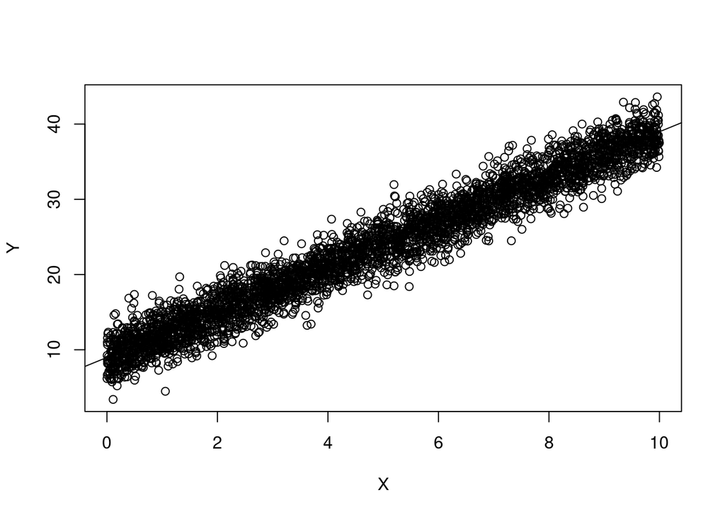

```
## Diagnostic #2: Do the Residuals Have Constant Variance?
##
##  Does the plot appear to be a general cloud of points or is there a megaphone shape?
```

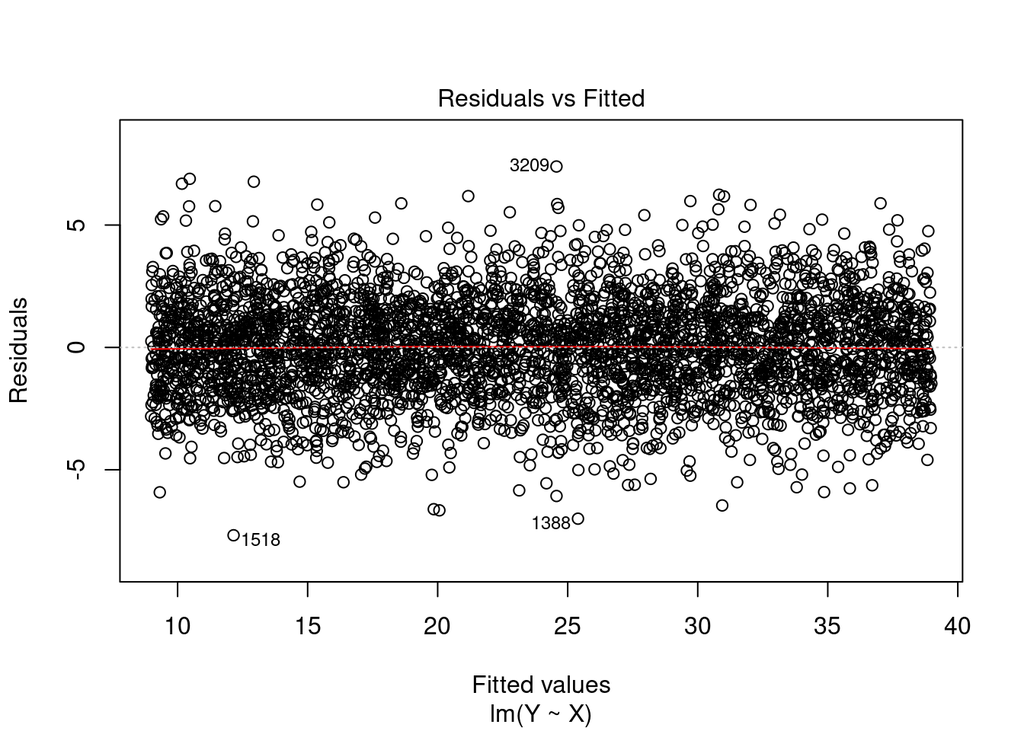

```
## Diagnostic #3: Are the Residuals Normally Distributed?
```

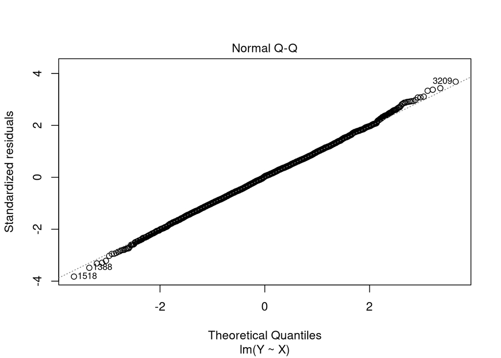

```
## Diagnostic #4: Are the Residuals Independent?
```

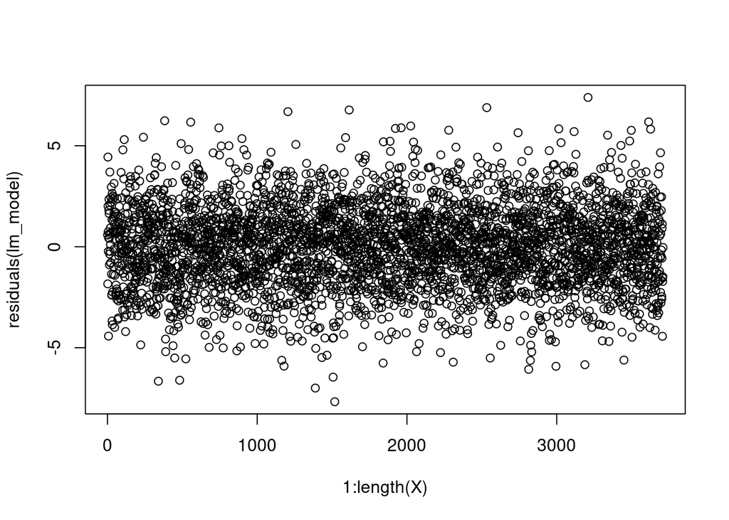

```r
plot_diagnostics(random_results1)
```

2. Non-normal errors
   1. Simulate errors from a variety of different non-normal distributions (e.g. gamma, poisson). Make sure to shift the errors over so that they are still centered at 0.
   2. Try simulations with a small sample size (e.g. 20), a medium sample size (e.g. n= 100), and a large sample size (e.g. n = 5000).
   3. For each simulation,
      1. Predict y-hat at several different locations using a confidence interval.
      2. Predict the beta coefficients for a linear model using a confidence interval.
      3. Find the MSE (to estimate sigma^2)
      4. Test to see whether the beta(s) are significant (t-tests)
   4. Which of the above tasks were affected by the violation of assumptions?
   5. After you have experimented with the effects of different model structures, true parameter values, and sample sizes, let’s repeat the simulation but test yourself to see whether you can detect non-normality.
      1. Have R randomly choose whether to simulate data with normal or nonnormal errors
      2. Simulate data accordingly and display informal/ formal diagnostics as appropriate.
      3. Based on the diagnostics, predict whether the problem areas you mentioned in part d will be affected or not. (Note: You are not predicting whether the assumptions are violated– just whether they are violated to such an extent that your ability to use the model is compromised)